# DWEI5_Aula01_Flask-Introducao

Instituto Federal de São Paulo (IFSP)  
[Campus Bragança Paulista/SP](https://bra.ifsp.edu.br)  
**Análise e Desenvolvimento de Sistemas (ADS)**  
**5o. módulo**  
**Profa. Ana Paula Müller Giancoli**  
paulagiancoli@ifsp.edu.br

## AULA 01 - INTRODUÇÃO AO FLASK

### Agenda

- Apresentação Flask
  - O que é um micro-framework
  - Como o Jinja funciona
  - Requisitos para utilizar Flask no componente curricular
- Criando o Primeiro App Flask
  - Passo 1: Criando a estrutura organizacional do projeto
  - Passo 2: Criando e ativando o ambiente virtual
  - Passo 3: Instalando os pacotes por meio do PIP
  - Passo 4: Criando o arquivo inicial __init__.py
  - Passo 5: Executando o Primeiro App Flask
- Perguntas

### 1.1. Apresentação FLASK

- Na tradução literal significa *Frasco*.
- De acordo com [Andrade, Ana Paula (2019)](https://www.treinaweb.com.br/blog/o-que-e-flask/), o Flask é um micro-framework multiplataforma que provê um modelo simples para o desenvolvimento web.
- Desenvolvido com a linguagem de programação Python e distribuído sob a licença BSD (Licença de código aberto).
- Foi lançado em 2010, e desenvolvido por [Armin Ronacher](https://github.com/mitsuhiko).
- Ronacher ganhou fama ao lançar uma comunidade de entusiastas do Python, conhecida como [Poocco](https://lucumr.pocoo.org/about/).
- Ainda segundo [Blog.geekhunter (2020)](https://blog.geekhunter.com.br/flask-framework-python/), assista a apresentação de [Eduardo Mendes](https://youtu.be/Snxl0T8ugeI), na FlaskConf 2019, para saber mais sobre seu criador, suas bases e parte estrutural do *framework*.

### 1.2. O que é um micro-framework ?

- De acordo com [Andrade, Ana Paula (2019)](https://www.treinaweb.com.br/blog/o-que-e-flask/), são *frameworks* modularizados com uma estrutura simplificada quando comparado com um *framework* tradicional.
- Versão minimalista.
- Útil para criação de microserviços, como APIs RESTful. Leia sobre o que é API, REST, RESTful com [Pires, jackson (2018)](https://becode.com.br/o-que-e-api-rest-e-restful/).
- Inicialmente criamos um projeto simples, básico e à medida que necessita de serviços e demais aplicações, por exemplo: conexão com banco de dados, envio de email, validação de login, efetua-se as importações de bibliotecas desenvolvidas por terceiros para compor a aplicação.
- Conforme [Blog.geekhunter (2020)](https://blog.geekhunter.com.br/flask-framework-python/), na utilização de algumas bibliotecas -- extensões, o Flask é ideal para quem busca:
  - Simplicidade.
  - Rapidez.
  - Soluções para projetos pequenos.
  - Aplicações robustas.
- O Flask baseia-se no kit de ferramentas: **WSGI** e **Werkzeug**, **Jinja2**.

[output not shown]

### 1.3. Como o Jinja funciona ?

- De acordo com [Pinheiro, Fagner (2020)](https://www.treinaweb.com.br/blog/o-que-e-o-jinja2/), o Jinja permite incorporar o código Python em páginas HTML e utilizar algumas características da linguagem nos templates.
- Por exemplo:
  - Permite o uso de estruturas de condição e repetição em páginas HTML.
  - É possível utilizar herança de layouts, garantindo uma estrutura com o maior reaproveitamento de código possível.
  - Permite exibir o conteúdo de variáveis Python em páginas HTML.
  - Sistema de blocos de templates, dentre outros.

### 1.3.1. Exemplo do uso do Jinja

```
<ul>
{% for pagina in lista_de_pagina %}
  <li><a href="{{ pagina.url }}">{{ pagina.nomecompleto }}</a></li>
{% endfor %}
</ul>
```

[output not shown]

#### Observação:

- Utilize: **{{** nome_da_variavel **}}** aberturas de chaves duplas e fechamento para manipular variáveis.
- Utilize: **{%** for variavel in lista **%}** aberturas de chaves e percentual e percentual chaves para fechamento para manipular estruturas de códigos python
- Utilize: **{% block nome %}** ... **{% endblock %}** para definir partes de códigos da estrutura do HTML.

```
{% for variavel in lista %}
    Hello, {{ nome }} !!!
{% endfor %}
```

```
{% block body %}
    <h1>Titulo</h1>
    <div>
        <p>Aproveite !!</p>
    </div>
{% endfor %}
```

### 1.4. Para o componente curricular: Requisitos para desenvolver com Flask

#### Instalar os seguintes itens:

- **Github**:
  - [Github](http://www.git-scm.com/downloads): Faça a instalação do git para utilizar linhas de comando, bem como uma interface [GUI client](http://www.git-scm.com/downloads/guis) para facilitar as atualizações e controle de versões.
  - Consulte também: No Youtube, o [Prof. José de Assis], [Curso Git e Github - Como instalar e configurar o GIT no windos](https://youtu.be/SOxafinthys).
- **Python 3.X**:
  - Efetue a instalação do Python, versão 3.7 no mínimo. Para instalar no windows, consulte [Python Brasil](https://python.org.br/instalacao-windows/) para auxiliar na instalação.
  - **Python**:
    - Para efetuar o download do Python de acordo com seu SO, consulte [Python | PIP](https://www.python.org/downloads/).
    - Em seguida, verifique se foi bem instalada, digitando no menu Iniciar: **cmd**. Selecione **Prompt de Comando**.
    - No **Prompt de Comando**: digite **python --version**. Verifique se a versão está correta.
  - **PIP**:
    - O PIP é um gerenciador de pacotes para projetos Python. É instalado em conjunto com o Python. É com ele que instalamos, removemos e atualizamos pacotes em nossos projetos. É similar aos conhecidos npm e composer (php), por exemplo.
    - No **Prompt de Comando**: digite **pip --version**. Verifique se a versão está correta. (Obs.: consulte [Treinaweb (2018)](https://www.treinaweb.com.br/blog/gerenciando-pacotes-em-projetos-python-com-o-pip/).)
  - **VENV**:
    - O Ambiente Virtual (**venv**) serve para controlarmos os pacotes instalados conforme versões. Empacota todas as dependências que um projeto precisa e armazena em um diretório, fazendo com que nenhum pacote seja instalado diretamente no sistema operacional. Sendo assim, cada projeto pode possuir seu próprio ambiente e, consequentemente, suas bibliotecas em versões específicas. O venv é instalado ao instalar o Python3.X. (Obs.: consulte [Treinaweb (2018)](https://www.treinaweb.com.br/blog/criando-ambientes-virtuais-para-projetos-python-com-o-virtualenv/). Ou veja o video do [Miranda, Otavio (2020)](https://youtu.be/m1TYpvIYm74) no Youtube para compreender o funcionamento.)
    - Consulte [Python.org](https://docs.python.org/pt-br/3/library/venv.html) para saber mais sobre criação de ambientes virtuais.
    - Consulte [Oliveira, Nadia](https://www.alura.com.br/artigos/ambientes-virtuais-em-python?gclid=Cj0KCQiApsiBBhCKARIsAN8o_4idgzWpfhMDyUg_EPb5ATDT26oSQNaYkJLbur8RzuoryFTzc_Oxd8oaAufIEALw_wcB) para saber mais sobre Ambientes Virtuais com Python.

#### Criar um arquivo com as seguintes instruções:

- **Arquivo** a ser utilizado dentro de cada novo projeto:
  - Criar uma única vez e depois replicar nas pastas quando for necessário.
  - No Windows, criar o arquivo **instalar.bat** por meio de um editor de texto, e ao salvar, substituir .txt por .bat. (**Comando de execução de dentro do ambiente virtual ativo: dois cliques sobre instalar.bat**)
  - No MacOS, criar o arquivo **instalar.sh** por meio de um editor de texto, e ao salvar, substituir .txt por .sh. (**Comando de execução de dentro do ambiente virtual ativo: bash instalar.sh**)
  - Conteúdo do arquivo **instalar.bat ou instalar.sh**:

    ```
      pip install --upgrade pip
      pip install Flask
      pip install Flask-SQLAlchemy
      pip install Flask-Migrate
      pip install Flask-Script
      pip install passlib
      pip install Flask-admin
      pip install Flask-Bootstrap4
      pip install pyjwt
      pip install Flask-login
      pip install sendgrid
      pip install Flask-mail
      pip install "tablib[all]"
    ```

#### Documentação:

| Instrução | Link Documentação |
| --- | --- |
| pip install --upgrade pip |  |
| pip install Flask | [flask](https://flask.palletsprojects.com/en/1.1.x/) |
| pip install Flask-SQLAlchemy | [flask-sqlalchemy](https://flask-sqlalchemy.palletsprojects.com/en/2.x/) |
| pip install Flask-Migrate | [flask-migrate](https://flask-migrate.readthedocs.io/en/latest/) |
| pip install Flask-Script | [flask-script](https://flask-script.readthedocs.io/en/latest/) |
| pip install passlib | [flask-passlib](https://pypi.org/project/Flask-Passlib/) e [PassLib](https://passlib.readthedocs.io/en/stable/install.html) |
| pip install Flask-admin | [flask-admin](https://flask-admin.readthedocs.io/en/latest/) |
| pip install Flask-bootstrap | [flask-bootstrap](https://pythonhosted.org/Flask-Bootstrap/) |
| pip install pyjwt | [pyjwt](https://pyjwt.readthedocs.io/en/stable/) |
| pip install Flask-login | [flask-login](https://flask-login.readthedocs.io/en/latest/) |
| pip install sendgrid | [sendgrid](https://pypi.org/project/sendgrid/) |
| pip install Flask-mail | [flask-mail](https://pythonhosted.org/Flask-Mail/) |

#### Observação:

- Para trabalhar com projetos grandes torna-se necessário modularizar a aplicação separando as responsabilidades em arquivos diferentes, no Flask esse conceito é chamado de **Blueprints**. As **Blueprints são aplicações em Flask que se acoplam em uma aplicação principal**.

#### Exemplos:

- No arquivo **__init__.py** da pasta do app:

```
# blueprint para adicionar rotas autenticadas no app
from app.controllers.auth import auth as auth_blueprint
app.register_blueprint(auth_blueprint)

# blueprint para adicionar rotas nao autenticadas no appfor non-auth parts of app
from app.controllers.controls import controls as controls_blueprint
app.register_blueprint(controls_blueprint)
```

- No arquivo **controls.py** da pasta do app >> controllers:

```
controls = Blueprint('controls', __name__)
```

- No arquivo **auth.py** da pasta do app >> controllers:

```
auth = Blueprint('auth', __name__)
```

### 2. Criando o Primeiro App Flask

- Ao criar seu projeto pelo Pycharm, novo projeto flask, o mesmo cria na pasta de seu projeto:
  - Duas outras pastas:
    - **static**: serão inseridos nesta pasta, os arquivos css, js e outros estáticos.
    - **templates**: serão inseridos nesta pasta, os arquivos HTML.
  - E um arquivo nomeado:
    - **app.py**.
- Para verificar o funcionamento, basta clicar sobre a setinha para executar o servidor e o arquivo da aplicação.
- Criando sua aplicação com Pycharm, consulte [Treinaweb (2019)](https://www.treinaweb.com.br/blog/criando-primeira-app-com-flask/).
- O **Flask** não tem uma estrutura definida como obrigatória, você quem pode definir como será a estrutura organizacional de seu projeto dentro das pastas, bem como o modelo de implementação.
- Vamos utilizar o MVC:
  - **M - Model: models**: a pasta **models** armazenará os modelos das classes que serão utilizados para a criação do banco de dados e suas tabelas.
  - **V - View: templates**: a pasta **templates**, que englobará as páginas HTMLs criadas para o projeto.
  - **C - Controller: controllers**: a pasta **controllers** será a pasta que conterá a lógica da aplicação, bem como a definição das rotas.

### Passo 1: Criando a estrutura organizacional do projeto

- Crie uma pasta nomeada:
  - **projeto**.
- Dentro da pasta projeto, crie uma pasta nomeada:
  - **app**.
- Abra o **terminal** ou o **prompt do windows**, acesse a pasta **projeto**.
  - No caso de dúvidas sobre quais comandos ou instruções a utilizar no terminal e prompt do windows:
    - Consulte para windows: **Materiais de Apoio** na página do [Github Ana Giancoli](https://anagiancoli.github.io).
    - E para Mac OS, consulte: **Comandos e Atalhos Mac OS** na página do [Github Ana Giancoli](https://anagiancoli.github.io).

### Passo 2: Criando e ativando o ambiente virtual

- Dentro da pasta **projeto** execute a instrução **python3 -m venv nomeambientevirtual**, onde **nomeambientevirtual** poderá ser o nome que desejar para o seu ambiente virtual. Este será usado sempre que iniciarmos o servidor Flask.

```
#Executando a instrução
python3 -m venv venv
```

- A pasta **venv** será criada dentro da pasta **projeto**.
- Para **ativar** o ambiente virtual **venv**, digite a instrução:

#### No **Mac OS**: ainda dentro da pasta **projeto**, digite: **source nomeambientevirtual/bin/activate**. Neste exemplo **nomeambientevirtual** será **venv**.

```
#Executando a instrução
source venv/bin/activate
```

#### No **Windows**: ainda dentro da pasta **projeto**, digite: **source nomeambientevirtual\Scripts\Activate**. Neste exemplo **nomeambientevirtual** será **venv**.

```
#Executando a instrução
source venv\Scripts\Activate
```

- Para **desativar** o ambiente virtual **venv**, digite a instrução: **deactivate**.
- Consulte o vídeo no Youtube do [Miranda, Otavio (2020)](https://youtu.be/m1TYpvIYm74) no Youtube para compreender o funcionamento.
- Após a **ativação** do ambiente virtual, pode ser feita as instalações dos pacotes a serem utilizados.

### Passo 3: Instalando os pacotes por meio do PIP

- No **Prompt de Comando**: digite **pip --version**. Verifique se a versão está correta. (Obs.: consulte [Treinaweb (2018)](https://www.treinaweb.com.br/blog/gerenciando-pacotes-em-projetos-python-com-o-pip/).)
- Instalando o Flask.
- Com o **ambiente virtual ativo**, execute de dentro da pasta **projeto**:
  - **pip install flask**
- Como saída, após a instalação:

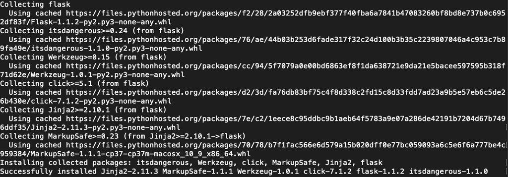

### Passo 4: Criando o arquivo inicial __init__.py

- Utilizando um editor ou IDE para criação dos códigos Python.
- Na pasta **app**: crie o primeiro arquivo **__init__.py**.
- **Observação**: Lembrando que em Python, quando inserimos em cada pasta um arquivo **__init__.py** mesmo que sem conteúdo, estamos indicando ao Python que aquela pasta faz parte do pacote da aplicação. Logo, ao utilizarmos as instruções de importação, o Python irá considerar estas pastas em suas pesquisas.
- Inserir o seguinte código:

```
# arquivo app/__init__.py
from flask import Flask

app = Flask(__name__)

@app.route("/")
@app.route("/index")
def index():
    return 'Sejam bem vindos alunos do 5o. módulo do ADS!'

if __name__ == "__main__":
    app.run()
```

### O que contém o arquivo inicial __init__.py ?

#### 1. Importando o flask:

```
from flask import Flask
```

#### 2. __name__ : indica o pacote onde a aplicação está:

```
app = Flask(__name__)
```

#### 3. Criando a primeira rota, no caso, a raiz da aplicação. Quando criamos rotas seguidas uma da outra, elas acessam a mesma requisicao HTTP:

```
@app.route("/")
@app.route("/index")
```

#### 4. Criamos uma função com mesmo nome da rota para manter padrão e facilitar o entendimento:

```
def index( ):
    return 'Sejam bem vindos alunos do 5o. módulo do ADS!'
```

#### 5. Verificamos se o arquivo app.py está sendo executado pelo terminal e, caso positivo, iniciamos o servidor do Flask:

```
if __name__ == "__main__":
    app.run()
```

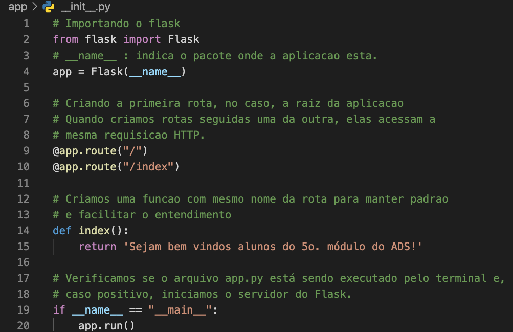

### Passo 5: Executando o Primeiro App Flask

- Em seguida, acessamos a pasta **app**, e executamos:

```
python3 __init__.py
```

- O servidor flask será iniciado.

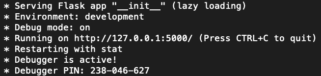

- Copie e cole no navegador: **http://127.0.0.1:5000/**

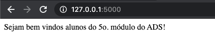

### ATENÇÃO

- **Lembre-se de encerrar o servidor ao final de cada aula**.
- **Lembre-se também, de desativar o ambiente virtual**.

### Referências

- Esta aula foi elaborada a partir do conteúdo disponibilizado em cada um dos links indicados no próprio texto.

### Perguntas

- Esclareça suas eventuais dúvidas durante as aulas.
- Ou pelo *E-mail*: paulagiancoli@ifsp.edu.br.
- Ou acesse [Github Ana Giancoli](https://anagiancoli.github.io) e solicite atendimento para o componente curricular.

*ADS - HTML5, CSS3, JS, FLASK - 5o. módulo*.  
Modelo e formato elaborado por profa. Ana Paula Müller Giancoli - BSD 2-Clause License. - Fevereiro.2021.